# Statistical Rethinking - Chapter 4 Questions

## Question 3

Suppose a colleague of yours, who works on allometry, glances at the practice problems just above. Your colleague exclaims, “That’s silly. Everyone knows that it’s only the logarithm of body weight that scales with height!” Let’s take your colleague’s advice and see what happens.

1. Model the relationship between height (cm) and the natural logarithm of weight (log-kg). Use the entire Howell1 data frame, all 544 rows, adults and non-adults. Fit this model, using quadratic approximation: hi ~ Normal(mu(i); sigma) mu(i) = a + b log(wi) a ~ Normal(178; 100) b ~ Normal(0; 100) sigma ~ Uniform(0; 50) where h(i) is the height of individual i and w(i) is the weight (in kg) of individual i. The function for computing a natural log in R is just log. Can you interpret the resulting estimates?

```r
set.seed(89)

flist3 <- alist(
  height ~ dnorm(mu, sigma),
  mu <- a + b*log(weight),
  a ~ dnorm(0, 100),
  b ~ dnorm(40, 40),
  sigma ~ dunif(0,50)
)

m4.3 <- map(flist3, d)
# When weight = 1 then the predicted height will be a.
```

2. Begin with this plot: R code plot( height ~ weight , data=Howell1 , col=col.alpha(rangi2,0.4) ) Then use samples from the quadratic approximate posterior of the model in (a) to superimpose on the plot:
1. the predicted mean height as a function of weight,

```r
weight.seq2 <- seq(from = 1, to = 70, by = 1)
mu2 <- link(m4.3, data=data.frame(weight = weight.seq2))
```

[output not shown]

```r
mu.mean2 <- apply( mu2 , 2 , mean )
mu.HPDI2 <- apply( mu2 , 2 , HPDI , prob=0.97 )
weight_modeled2 = data.frame(weight = weight.seq2, mean = mu.mean2, hdpi=t(mu.HPDI2))
colnames(weight_modeled2) <- c("weight","mean","lower","upper")

# ppc
post <- extract.samples( m4.3 )
sim.height <- data.frame(weight = 1:70, t(apply(sim(m4.3, list(weight = weight.seq2)), 2, PI)))
```

[output not shown]

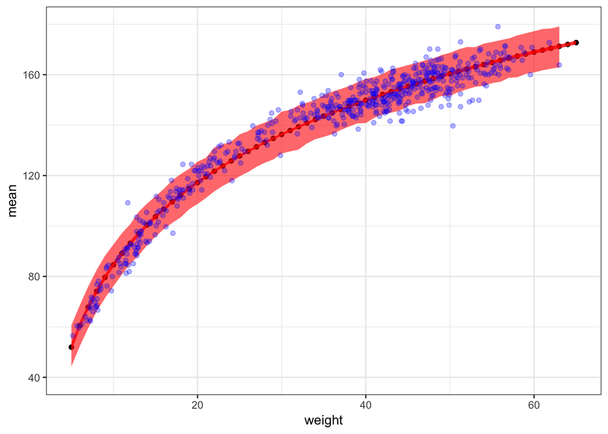

```r
colnames(sim.height) <- c ("weight", "sim_lower", "sim_upper")

weight_modeled2 <- merge(weight_modeled2, sim.height, by="weight")

ggplot(weight_modeled2, aes(x=weight, y=mean)) +
  geom_point() +
  geom_ribbon(aes(ymin=lower, ymax=upper), alpha=0.8, fill='red') +
  geom_ribbon(aes(ymin=sim_lower, ymax=sim_upper), alpha=0.6, fill="red") +
  geom_point(data=d, aes(x=weight, y=height), col="blue", alpha=0.3) +
  theme_bw() +
  xlim(5, 65) +
  ylim(40, 180)
```

2. the 97% HPDI for the mean, and
3. the 97% HPDI for predicted heights.